# STAT 331 Portfolio

- `left_join()` Example 1

```r
# Lab 5 - Inspecting the Crime Scene (Revised for Portfolio)
get_fit_now_member |>
  filter(membership_status == "gold",                  # Find all gold members with a membership
         str_sub(id, start = 1, end = 3) == "48Z") |>  # number that start with 48Z
  left_join(person,
            join_by(person_id == id, name)) |>         # Use person data to find associated license
  left_join(drivers_license,                           # Use license data to find suspect with plate
            join_by(license_id == id))  |>             # number that includes "H42"
  filter(str_detect(plate_number,
                    pattern = "H42W")) |>
  left_join(get_fit_now_check_in,                      # Check that date matches statement from
            join_by(id == membership_id)) |>           # second witness
  filter(ymd(check_in_date) == "2018-01-09") |>
  left_join(interview,
            join_by(person_id)) |>                     # Retrieve suspect interview
  select(transcript)   |>                              # View interview transcript
  kable(col.names = "Clue #4")
```

- `right_join()` Example 1

```r
# Lab 5 - Investigating the Witnesses (Revised for Portfolio)
person |>
  right_join(y = interview,
             by = join_by(id == person_id)) |>
  filter(address_street_name == "Northwestern Dr" &
           address_number == max(address_number) |
         address_street_name == "Franklin Ave" &
           str_detect(name, pattern = "Annabel"))  |>
  select(transcript)  |>
  kable(col.names = "Clue #2 & Clue #3")
```

- `left_join()` **or** `right_join()` Example 2

```r
# Lab 5 - Investigating the Witnesses
# Searching for Witness 1
person |>
  filter(address_street_name == "Northwestern Dr") |>  # Find first witness
  slice_max(address_number) |>
  left_join(y = interview,                             # Search for interview by person_id
            by = join_by(id == person_id)) |>
  select(transcript)  |>                               # View interview transcript
  kable(col.names = "Clue #2")

# Searching for Witness 2
person |>
  filter(address_street_name == "Franklin Ave",        # Find second witness
         str_detect(name,
                    pattern = "Annabel")) |>
  left_join(y = interview,                             # Search for interview by person_id
            by = join_by(id == person_id)) |>
  select(transcript)  |>                               # View interview transcript
  kable(col.names = "Clue #3")
```

- `inner_join()` Example 1

```r
# Lab 5 - Inspecting the Crime Scene (Revised for Portfolio)
get_fit_now_member |>
  filter(membership_status == "gold",                  # Find all gold members with a membership
         str_sub(id, start = 1, end = 3) == "48Z") |>  # number that start with 48Z
  inner_join(person,
            join_by(person_id == id, name)) |>         # Use person data to find associated license
  inner_join(drivers_license,                           # Use license data to find suspect with plate
            join_by(license_id == id))  |>             # number that includes "H42"
  filter(str_detect(plate_number,
                    pattern = "H42W")) |>
  inner_join(get_fit_now_check_in,                      # Check that date matches statement from
            join_by(id == membership_id)) |>           # second witness
  filter(ymd(check_in_date) == "2018-01-09") |>
  inner_join(interview,
            join_by(person_id)) |>                     # Retrieve suspect interview
  select(transcript)   |>                              # View interview transcript
  kable(col.names = "Clue #4")
```

- `inner_join()` Example 2

```r
# Lab 5 - Investigating the Witnesses (Revised for Portfolio)
person |>
  filter(address_street_name == "Northwestern Dr" &
           address_number == max(address_number) |
         address_street_name == "Franklin Ave" &
           str_detect(name, pattern = "Annabel"))  |>
  inner_join(y = interview,
             by = join_by(id == person_id)) |>
  select(transcript)  |>
  kable(col.names = "Clue #2 & Clue #3")
```

**WD-6: I can use filtering joins to filter rows from a dataframe.**

- `semi_join()`

```r
# Lab 3 Question 12 (Revised for Portfolio)

right_degrees <- tibble(academic_degree = c("prof","dr"))

teacher_evals_clean |>
  group_by(teacher_id, seniority, sex) |>
  semi_join(right_degrees,
            by = join_by(academic_degree)) |>
  summarize(resp_rate = mean(resp_share),
            .groups = "drop") |>
  filter(resp_rate == max(resp_rate) |
         resp_rate == min(resp_rate)) |>
  arrange(resp_rate) |>
  kable()
```

- `anti_join()`

```r
# Lab 3 Question 12 (Revised for Portfolio)

wrong_degrees <- tibble(academic_degree = c("ma","no_dgr"))

teacher_evals_clean |>
  group_by(teacher_id, seniority, sex) |>
  anti_join(wrong_degrees,
            by = join_by(academic_degree)) |>
  summarize(resp_rate = mean(resp_share),
            .groups = "drop") |>
  filter(resp_rate == max(resp_rate) |
         resp_rate == min(resp_rate)) |>
  arrange(resp_rate) |>
  kable()
```

**WD-7: I can pivot dataframes from long to wide and visa versa**

- `pivot_longer()`

```r
# Lab 4 Revision Question 7
colors <- colorRampPalette(RColorBrewer::brewer.pal(7, "Accent"))(10) # color palette

ca_childcare |>
  select(census_region,
         county_name,
         study_year,
         Infant = mc_infant,
         Toddler = mc_toddler,
         Preschool = mc_preschool) |>
  pivot_longer(cols = c(Infant, Toddler, Preschool),
               names_to = "age_group",
               values_to = "median_price") |>
  mutate(age_group = fct(age_group,
                         levels = c("Infant", "Toddler", "Preschool")),
         census_region = fct_reorder2(.f = census_region,
                                     .x = study_year,
                                     .y = median_price,
                                     .desc = TRUE)) |>
  ggplot(mapping = aes(x = study_year, y = median_price, color = census_region)) +
  geom_point(size = 0.5) +
  geom_smooth(linewidth = 0.5) +
  facet_wrap(vars(age_group)) +
  theme_bw() +
  theme(aspect.ratio = 1,
        axis.text.x = element_text(size = 6),
        axis.text.y = element_text(size = 6),
        title = element_text(size = 8),
        legend.title = element_text(size = 10),
        legend.key.size = unit(0.4, "cm")) +
  scale_x_continuous(n.breaks = 7) +
  scale_y_continuous(limits = c(100,500)) +
  scale_color_manual(values = colors,
                     labels = c("San Francisco Bay Area",
                                "Orange County",
                                "Los Angeles County",
                                "North San Joaquin Valley",
                                "Central Coast",
                                "Inland Empire",
                                "Superior California",
                                "South San Joaquin Valley",
                                "San Diego - Imperial",
                                "North Coast")) +
  labs(x = "Study Year",
       y = NULL,
       title = "Weekly Median Price for Center-Based Childcare ($)",
       color = "Calfornia Region")
```

- `pivot_wider()`

```r
# Lab 4 Question 5
ca_childcare |>
  filter(study_year %in% c("2008", "2018")) |>
  group_by(census_region, study_year)  |>
  summarize(median_household_inc = median(mhi_2018),
            .groups = "drop") |>
  pivot_wider(names_from = study_year,
              values_from = median_household_inc,
              names_prefix = "median_income_") |>
  arrange(desc(median_income_2018))
```

## Reproducibility

**R-1: I can create professional looking, reproducible analyses using RStudio projects, Quarto documents, and the here package.**

The following assignments satisfy the above criteria:

- Lab 2
- Lab 3
- Lab 5
- Lab 7
- Lab 9

**R-2: I can write well documented and tidy code.**

- Example of **ggplot2** plotting

```r
# Challenge 4 Analysis (Revised for Portfolio)
childcare2018 |>
  pivot_longer(cols = c("center_based_care","family_childcare"),
               names_to = "care_type",
               values_to = "price")  |>
  mutate(care_type = fct(care_type)) |>
  ggplot(mapping = aes(x = price, y = age_group, fill = care_type)) +
  geom_boxplot(outliers = FALSE) +
  geom_jitter(mapping = aes(color = care_type),
              size = 0.75,
              alpha = 1,
              position = position_jitterdodge()) +
  theme_bw() +
  labs(x = NULL,
       y = NULL,
       title = "Center-Based Childcare: Significantly More Expensive",
       fill = "Type of Care") +
  guides(color = "none") +
  scale_color_manual(values = c("#96475D","#3C3E78")) +
  scale_fill_manual(values = c(family_childcare = "#BFC1FF", center_based_care = "#FFABC3"),
                    limits = c("family_childcare", "center_based_care"),
                    labels = c("Family Childcare", "Center-Based Care")) +
  scale_x_continuous(labels = label_currency)
```

- Example of **dplyr** pipeline

```r
# Lab 5 - Inspecting the Crime Scene (Revised for Portfolio)
get_fit_now_member |>
  filter(membership_status == "gold",                  # Find all gold members with a membership
         str_sub(id, start = 1, end = 3) == "48Z") |>  # number that start with 48Z
  left_join(person,
            join_by(person_id == id, name)) |>         # Use person data to find associated license
  left_join(drivers_license,                           # Use license data to find suspect with plate
            join_by(license_id == id))  |>             # number that includes "H42"
  filter(str_detect(plate_number,
                    pattern = "H42W")) |>
  left_join(get_fit_now_check_in,                      # Check that date matches statement from
            join_by(id == membership_id)) |>           # second witness
  filter(ymd(check_in_date) == "2018-01-09") |>
  left_join(interview,
            join_by(person_id)) |>                     # Retrieve suspect interview
  select(transcript)   |>                              # View interview transcript
  kable(col.names = "Clue #4")
```

- Example of function formatting

```r
# Challenge 7 Question 2 Revisions
impossible_to_NA <- function(x, min, max) {

  stopifnot("Input vector is not numeric" = is.numeric(x),
            "Min is not a scalar value" =  is.numeric(min),
            "Min is not a scalar value" = length(min) == 1,
            "Max is not a scalar value" =  is.numeric(max),
            "Max is not a scalar value" = length(max) == 1,
            "Max is not greater than min" = max > min)

   case_when(x < min ~ NA,
             x > max ~ NA,
             .default = x)

}
```

**R-3: I can write robust programs that are resistant to changes in inputs.**

- Example (any context)

```r
# Feedback: Is there a way you can get the max *and* min in **one** pipeline?
# Revision Reflection (for Q10, Q11, & Q12): I thought that the
# best way to get the max and min values were to use the slice_min
# and slice_max functions. However, you cannot use both in one
# pipeline. I learned that the min() and max() functions can be
# used inside the filter function to output all of the observations
# equal to highest and lowest values in one pipeline. Doing so
# allows me to print the ties and also reduce the number of objects
# in my code.

# Lab 3 - Question 12
teacher_evals_clean |>
  group_by(teacher_id, seniority, sex) |>
  filter(academic_degree %in% c("prof", "dr")) |>
  summarize(resp_rate = mean(resp_share),
            .groups = "drop") |>
  filter(resp_rate == max(resp_rate) |
         resp_rate == min(resp_rate)) |>
  arrange(resp_rate) |>
  kable()
```

- Example (function stops)

```r
# Challenge 7 Question 2 Revisions
impossible_to_NA <- function(x, min, max) {

  stopifnot("Input vector is not numeric" = is.numeric(x),
            "Min is not a scalar value" =  is.numeric(min),
            "Min is not a scalar value" = length(min) == 1,
            "Max is not a scalar value" =  is.numeric(max),
            "Max is not a scalar value" = length(max) == 1,
            "Max is not greater than min" = max > min)

   case_when(x < min ~ NA,
             x > max ~ NA,
             .default = x)
}
```

## Data Visualization & Summarization

**DVS-1: I can create visualizations for a *variety* of variable types (e.g., numeric, character, factor, date)**

- At least two numeric variables

```r
# Lab 4 Revisions Question 8
ca_childcare |>
  ggplot(mapping = aes(x = mhi_2018, y = mc_infant)) +
  geom_point(size = 0.75) +
  geom_smooth(method = "lm") +
  theme_bw() +
  labs(x = "Median Household Income (in 2018 dollars)",
       y = NULL,
       title = "Median Weekly Price for Center-based Childcare for Infants in California") +
  scale_x_continuous(labels = label_currency()) +
  scale_y_continuous(labels = label_currency())
```

- At least one numeric variable and one categorical variable

```r
# Challenge 2 (Revised for Portfolio)
ggplot(data = surveys,
       mapping = aes(x = weight, y = species)) +
   geom_jitter(color = "darkslateblue", alpha = 0.5, size = 0.5) +
   geom_boxplot(outliers = FALSE, linewidth = 0.25, color = "gray10") +
   labs(x = "Weight (g)",
        y = "",
        subtitle = "Rodent Species",
        title = "Heaviest Portal, AZ Rodents: Abigula, Spectabilis, and Hispidus") +
   theme_bw() +
   theme(plot.title = element_text(face = "bold",                     # title formatting
                                   size = 15,
                                   margin = margin(t = 10, b = 10)),
         axis.ticks = element_line(linewidth = 0.1),                  # axis label formatting
         axis.text = element_text(size = 7),
         panel.grid.major.y = element_line(linewidth = 0.1),          # remove y gridlines and border
         panel.border = element_rect(linewidth = 0.25))
```

- At least two categorical variables

```r
# Challenge 4 Analysis (Revised for Portfolio)
childcare2018 |>
  pivot_longer(cols = c("center_based_care","family_childcare"),
               names_to = "care_type",
               values_to = "price")  |>
  mutate(care_type = fct(care_type)) |>
  ggplot(mapping = aes(x = price, y = age_group, fill = care_type)) +
  geom_boxplot(outliers = FALSE) +
  geom_jitter(mapping = aes(color = care_type),
              size = 0.75,
              alpha = 1,
              position = position_jitterdodge()) +
  theme_bw() +
  labs(x = NULL,
       y = NULL,
       title = "Center-Based Childcare: Significantly More Expensive",
       fill = "Type of Care") +
  guides(color = "none") +
  scale_color_manual(values = c("#96475D","#3C3E78")) +
  scale_fill_manual(values = c(family_childcare = "#BFC1FF", center_based_care = "#FFABC3"),
                    limits = c("family_childcare", "center_based_care"),
                    labels = c("Family Childcare", "Center-Based Care")) +
  scale_x_continuous(labels = label_currency)
```

- Dates (time series plot)

```r
# Challenge 7 Question 5
mycolors <- RColorBrewer::brewer.pal(8, "BrBG")[c(3,2,1,8)] # color palette

fish |>
  mutate(condition = condition_index(length, weight)) |>
  group_by(year, species) |>
  summarize(mean_condition = mean(condition, na.rm = TRUE),
            .groups = "drop") |>
  mutate(species = fct_reorder2(.f = species,
                               .x = year,
                               .y = mean_condition)) |>
  ggplot(mapping = aes(x = year, y = mean_condition, color = species)) +
  geom_rug(sides = "b", color = "gray85", lineend = "round", length = unit(100, "npc")) +
  geom_smooth(se = FALSE) +
  geom_point() +
  theme_linedraw() +
  scale_color_manual(values = mycolors,
                     labels = c("Rainbow Trout",
                                "Brown Trout",
                                "Westslope Cutthroat Trout",
                                "Bull Trout")) +
  scale_x_continuous(breaks = seq(1988, 2007, by = 1)) +
  theme(axis.text.x = element_text(size = 7),
        panel.grid.minor.x = element_blank(),
        panel.grid.major.x = element_blank(),
        plot.title = element_text(face = "bold"),
        plot.caption.position = "plot") +
  labs(title = "Bull Trout in Worse Condition than Other Fish",
       subtitle = "Mean Condition Index",
       x = "Year",
       y = NULL,
       color = "Trout Species",
       caption = "Black Foot River Fish in Helena, Montana")
```

**DVS-2: I use plot modifications to make my visualization clear to the reader.**

- I can modify my plot theme to be more readable

```r
# Challenge 7 Question 5
mycolors <- RColorBrewer::brewer.pal(8, "BrBG")[c(3,2,1,8)] # color palette

fish |>
  mutate(condition = condition_index(length, weight)) |>
  group_by(year, species) |>
  summarize(mean_condition = mean(condition, na.rm = TRUE),
            .groups = "drop") |>
  mutate(species = fct_reorder2(.f = species,
                               .x = year,
                               .y = mean_condition)) |>
  ggplot(mapping = aes(x = year, y = mean_condition, color = species)) +
  geom_rug(sides = "b", color = "gray85", lineend = "round", length = unit(100, "npc")) +
  geom_smooth(se = FALSE) +
  geom_point() +
  theme_linedraw() +
  scale_color_manual(values = mycolors,
                     labels = c("Rainbow Trout",
                                "Brown Trout",
                                "Westslope Cutthroat Trout",
                                "Bull Trout")) +
  scale_x_continuous(breaks = seq(1988, 2007, by = 1)) +
  theme(axis.text.x = element_text(size = 7),
        panel.grid.minor.x = element_blank(),
        panel.grid.major.x = element_blank(),
        plot.title = element_text(face = "bold"),
        plot.caption.position = "plot") +
  labs(title = "Bull Trout in Worse Condition than Other Fish",
       subtitle = "Mean Condition Index",
       x = "Year",
       y = NULL,
       color = "Trout Species",
       caption = "Black Foot River Fish in Helena, Montana")
```

- I can modify my colors to be accessible to anyone’s eyes

```r
# Challenge 4 Analysis (Revised for Portfolio)
childcare2018 |>
  pivot_longer(cols = c("center_based_care","family_childcare"),
               names_to = "care_type",
               values_to = "price")  |>
  ggplot(mapping = aes(x = price, y = age_group, fill = care_type)) +
  geom_boxplot(outliers = FALSE) +
  geom_jitter(mapping = aes(color = care_type),
              size = 0.75,
              position = position_jitterdodge()) +
  theme_bw() +
  labs(x = NULL,
       y = NULL,
       title = "Median Weekly Price of California Childcare in 2018",
       fill = "Type of Care") +
  guides(color = "none") +
  scale_color_manual(values = c("#96475D","#3C3E78")) +
  scale_fill_manual(values = c("#FFABC3","#BFC1FF"),
                    labels = c("Center Based Care", "Family Childcare")) +
  scale_x_continuous(labels = label_currency())

# color deficiency vision test shown in images
```

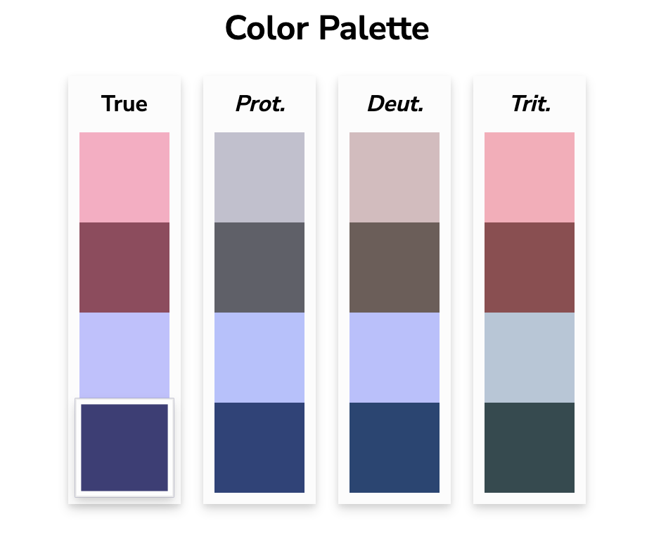

*Resource: Coloring for Colorblindness by David Nichols*

- I can modify my plot titles to clearly communicate the data context

```r
# Challenge 4 Analysis (Revised for Portfolio)
childcare2018 |>
  pivot_longer(cols = c("center_based_care","family_childcare"),
               names_to = "care_type",
               values_to = "price")  |>
  mutate(care_type = fct(care_type)) |>
  ggplot(mapping = aes(x = price, y = age_group, fill = care_type)) +
  geom_boxplot(outliers = FALSE) +
  geom_jitter(mapping = aes(color = care_type),
              size = 0.75,
              alpha = 1,
              position = position_jitterdodge()) +
  theme_bw() +
  labs(x = NULL,
       y = NULL,
       title = "Center-Based Childcare: Significantly More Expensive",
       fill = "Type of Care") +
  guides(color = "none") +
  scale_color_manual(values = c("#96475D","#3C3E78")) +
  scale_fill_manual(values = c(family_childcare = "#BFC1FF", center_based_care = "#FFABC3"),
                    limits = c("family_childcare", "center_based_care"),
                    labels = c("Family Childcare", "Center-Based Care")) +
  scale_x_continuous(labels = label_currency())
```

- I can modify the text in my plot to be more readable

```r
# Challenge 2 (Revised for Portfolio)
ggplot(data = surveys,
       mapping = aes(x = weight, y = species)) +
   geom_jitter(color = "darkslateblue", alpha = 0.5, size = 0.5) +
   geom_boxplot(outliers = FALSE, linewidth = 0.25, color = "gray10") +
   labs(x = "Weight (g)",
        y = "",
        subtitle = "Rodent Species",
        title = "Heaviest Portal, AZ Rodents: Abigula, Spectabilis, and Hispidus") +
   theme_bw() +
   theme(plot.title = element_text(face = "bold",                     # title formatting
                                   size = 15,
                                   margin = margin(t = 10, b = 10)),
         axis.ticks = element_line(linewidth = 0.1),                  # axis label formatting
         axis.text = element_text(size = 7),
         panel.grid.major.y = element_line(linewidth = 0.1),          # remove y gridlines and border
         panel.border = element_rect(linewidth = 0.25))
```

- I can reorder my legend to align with the colors in my plot

```r
# Challenge 7 Question 5
mycolors <- RColorBrewer::brewer.pal(8, "BrBG")[c(3,2,1,8)] # color palette

fish |>
  mutate(condition = condition_index(length, weight)) |>
  group_by(year, species) |>
  summarize(mean_condition = mean(condition, na.rm = TRUE),
            .groups = "drop") |>
  mutate(species = fct_reorder2(.f = species,
                               .x = year,
                               .y = mean_condition)) |>
  ggplot(mapping = aes(x = year, y = mean_condition, color = species)) +
  geom_rug(sides = "b", color = "gray85", lineend = "round", length = unit(100, "npc")) +
  geom_smooth(se = FALSE) +
  geom_point() +
  theme_linedraw() +
  scale_color_manual(values = mycolors,
                     labels = c("Rainbow Trout",
                                "Brown Trout",
                                "Westslope Cutthroat Trout",
                                "Bull Trout")) +
  scale_x_continuous(breaks = seq(1988, 2007, by = 1)) +
  theme(axis.text.x = element_text(size = 7),
        panel.grid.minor.x = element_blank(),
        panel.grid.major.x = element_blank(),
        plot.title = element_text(face = "bold"),
        plot.caption.position = "plot") +
  labs(title = "Bull Trout in Worse Condition than Other Fish",
       subtitle = "Mean Condition Index",
       x = "Year",
       y = NULL,
       color = "Trout Species",
       caption = "Black Foot River Fish in Helena, Montana")
```

**DVS-3: I show creativity in my visualizations**

- I can use non-standard colors (Example 1)

```r
childcare2018 |>
  pivot_longer(cols = c("center_based_care","family_childcare"),
               names_to = "care_type",
               values_to = "price")  |>
  mutate(care_type = fct(care_type)) |>
  ggplot(mapping = aes(x = price, y = age_group, fill = care_type)) +
  geom_boxplot(outliers = FALSE) +
  geom_jitter(mapping = aes(color = care_type),
              size = 0.75,
              alpha = 1,
              position = position_jitterdodge()) +
  theme_bw() +
  labs(x = NULL,
       y = NULL,
       title = "Center-Based Childcare: Significantly More Expensive",
       fill = "Type of Care") +
  guides(color = "none") +
  scale_color_manual(values = c("#96475D","#3C3E78")) +
  scale_fill_manual(values = c(family_childcare = "#BFC1FF", center_based_care = "#FFABC3"),
                    limits = c("family_childcare", "center_based_care"),
                    labels = c("Family Childcare", "Center-Based Care")) +
  scale_x_continuous(labels = label_currency())
```

- I can use non-standard colors (Example 2)

```r
# Challenge 7 Question 5
mycolors <- RColorBrewer::brewer.pal(8, "BrBG")[c(3,2,1,8)] # color palette

fish |>
  mutate(condition = condition_index(length, weight)) |>
  group_by(year, species) |>
  summarize(mean_condition = mean(condition, na.rm = TRUE),
            .groups = "drop") |>
  mutate(species = fct_reorder2(.f = species,
                               .x = year,
                               .y = mean_condition)) |>
  ggplot(mapping = aes(x = year, y = mean_condition, color = species)) +
  geom_rug(sides = "b", color = "gray85", lineend = "round", length = unit(100, "npc")) +
  geom_smooth(se = FALSE) +
  geom_point() +
  theme_linedraw() +
  scale_color_manual(values = mycolors,
                     labels = c("Rainbow Trout",
                                "Brown Trout",
                                "Westslope Cutthroat Trout",
                                "Bull Trout")) +
  scale_x_continuous(breaks = seq(1988, 2007, by = 1)) +
  theme(axis.text.x = element_text(size = 7),
        panel.grid.minor.x = element_blank(),
        panel.grid.major.x = element_blank(),
        plot.title = element_text(face = "bold"),
        plot.caption.position = "plot") +
  labs(title = "Bull Trout in Worse Condition than Other Fish",
       subtitle = "Mean Condition Index",
       x = "Year",
       y = NULL,
       color = "Trout Species",
       caption = "Black Foot River Fish in Helena, Montana")
```

- I can use annotations (e.g., `geom_text()`)

```r
# Lab 10 Question 3
results |>
  enframe(name = "simulation",
          value = "correct_number") |>
  count(correct_number) |>
  mutate(prop = n / 10000,
         correct_number = as.factor(correct_number)) |>
  select(correct_number, prop) |>
  ggplot(mapping = aes(x = correct_number, y = prop, fill = correct_number)) +
  geom_bar(stat = "identity") +
  geom_text(mapping = aes(label = str_c(prop*100, "%")), vjust = -0.5, size = 3) +
  theme_minimal() +
  labs(title = "So Many Wrong Babies!",
       subtitle = "Distribution of Correctly Returned Babies for 4 Births",
       y = NULL,
       x = "Correct Babies",
       caption = "10,000 simulations of Random Babies Simulation") +
  scale_y_continuous(labels = scales::label_percent()) +
  scale_fill_manual(values = RColorBrewer::brewer.pal(4, "Pastel2")) +
  theme(legend.position = "none",
        title = element_text(face = "bold"),
        panel.grid.major.x = element_blank())
```

- I can choose creative geometries (e.g., `geom_segment()`, `geom_ribbon)()`)

```r
# Lab 10 Question 13
set.seed(14)

ci_data |>
  slice_sample(n = 100) |>
  mutate(iteration = row_number(),
         cover = as.factor(cover)) |>
  ggplot() +
  geom_segment(mapping = aes(x = conf.low,
                             y = iteration,
                             xend = conf.high,
                             color = cover)) +
  geom_vline(mapping = aes(xintercept = 0.5), linetype = "dotted") +
  annotate("text",
           x = 0.5,
           y = 105,
           label = "Population Slope = 0.5",
           hjust = -0.05,
           size = 3) +
  theme_minimal() +
  labs(title = "95% Confidence Intervals of Estimated Regression Slope",
       x = "Slope Coefficient Estimate",
       y = NULL,
       subtitle = "<span style='color:#ED3B18;'> Red</span> =
                   Does Not Capture Population Slope",
       caption = "Constructed from 100 Simulated Data Sets") +
  theme(axis.text.y = element_blank(),
        legend.position = "none",
        panel.grid.major.y = element_blank(),
        panel.grid.minor.y = element_blank(),
        plot.subtitle = ggtext::element_markdown()) +
  scale_color_manual(values = RColorBrewer::brewer.pal(3, "Set1"))
```

**DVS-4: I can calculate numerical summaries of variables.**

- Example using `summarize()`

```r
# Lab 3 Question 5
teacher_evals_clean |>
  summarize(unique_instructors = n_distinct(teacher_id),
            unique_courses = n_distinct(course_id))
```

- Example using `across()`

```r
# Lab 3 Question 6 (Revised for Portfolio)
teacher_evals_clean |>
  summarize(across(.cols = c(teacher_id, course_id),
                   .fns = ~ n_distinct(.x))) |>
  kable(col.names = c("Unique Instructors", "Unique Courses"))
```

**DVS-5: I can find summaries of variables across multiple groups.**

- Example 1

```r
# Lab 3 Question 9
teacher_evals_clean |>
  group_by(course_id, teacher_id) |>
  summarize(num_question = n_distinct(question_no),
            .groups = "drop") |>
  filter(num_question == 9)
```

- Example 2

```r
# Lab 4 Question 6
ca_childcare |>
  filter(study_year == 2018) |>
  group_by(census_region, study_year) |>
  summarize(median_mc_infant = median(mc_infant),
            .groups = "drop") |>
  slice_min(median_mc_infant)
```

**DVS-6: I can create tables which make my summaries clear to the reader.**

- I can modify my column names to clearly communicate the data context

```r
fish |>
  map_int(.f = ~ sum(is.na(.x))) |>
  enframe(name = "variable",
          value = "missing_values") |>
  arrange(desc(missing_values)) |>
  gt() |>
  cols_label(variable = md("**Measurement Variable**"),
             missing_values = md("**Missing Values**")) |>
  data_color(columns = missing_values,
             rows = missing_values > 0,
             method = "numeric",
             palette = c("salmon3")) |>
  data_color(columns = missing_values,
             rows = missing_values == 0,
             method = "numeric",
             palette = c("honeydew4")) |>
  data_color(columns = variable,
             method = "factor",
             palette = c("gray60")) |>
  tab_style(style = list(cell_fill(color = "gray30"),
                         cell_text(color = "white",
                                   align = "center")),
            locations = cells_column_labels()) |>
  tab_header(title = md("**Missing Measurements of River Trout Population**"),
             subtitle = "Data on Blackfoot River Trout in Helena, Montana") |>
  tab_style(style = list(cell_fill(color = "gray20"), cell_text(color = "white")),
            locations = cells_title())
```

- I can modify the text in my table to be more readable (e.g., bold face for column headers)

```r
# Lab 9 Question 8
fish |>
  map_int(.f = ~ sum(is.na(.x))) |>
  enframe(name = "variable",
          value = "missing_values") |>
  arrange(desc(missing_values)) |>
  gt() |>
  cols_label(variable = md("**Measurement Variable**"),
             missing_values = md("**Missing Values**")) |>
  data_color(columns = missing_values,
             rows = missing_values > 0,
             method = "numeric",
             palette = c("salmon3")) |>
  data_color(columns = missing_values,
             rows = missing_values == 0,
             method = "numeric",
             palette = c("honeydew4")) |>
  data_color(columns = variable,
             method = "factor",
             palette = c("gray60")) |>
  tab_style(style = list(cell_fill(color = "gray30"),
                         cell_text(color = "white",
                                   align = "center")),
            locations = cells_column_labels()) |>
  tab_header(title = md("**Missing Measurements of River Trout Population**"),
             subtitle = "Data on Blackfoot River Trout in Helena, Montana") |>
  tab_style(style = list(cell_fill(color = "gray20"), cell_text(color = "white")),
            locations = cells_title())
```

- I can arrange my table to have an intuitive ordering

```r
# Lab 9 Question 8
fish |>
  map_int(.f = ~ sum(is.na(.x))) |>
  enframe(name = "variable",
          value = "missing_values") |>
  arrange(desc(missing_values)) |>
  gt() |>
  cols_label(variable = md("**Measurement Variable**"),
             missing_values = md("**Missing Values**")) |>
  data_color(columns = missing_values,
             rows = missing_values > 0,
             method = "numeric",
             palette = c("salmon3")) |>
  data_color(columns = missing_values,
             rows = missing_values == 0,
             method = "numeric",
             palette = c("honeydew4")) |>
  data_color(columns = variable,
             method = "factor",
             palette = c("gray60")) |>
  tab_style(style = list(cell_fill(color = "gray30"),
                         cell_text(color = "white",
                                   align = "center")),
            locations = cells_column_labels()) |>
  tab_header(title = md("**Missing Measurements of River Trout Population**"),
             subtitle = "Data on Blackfoot River Trout in Helena, Montana") |>
  tab_style(style = list(cell_fill(color = "gray20"), cell_text(color = "white")),
            locations = cells_title())
```

**DVS-7: I show creativity in my tables.**

- I can use non-default colors

```r
# Lab 9 Question 8
fish |>
  map_int(.f = ~ sum(is.na(.x))) |>
  enframe(name = "variable",
          value = "missing_values") |>
  arrange(desc(missing_values)) |>
  gt() |>
  cols_label(variable = md("**Measurement Variable**"),
             missing_values = md("**Missing Values**")) |>
  data_color(columns = missing_values,
             rows = missing_values > 0,
             method = "numeric",
             palette = c("salmon3")) |>
  data_color(columns = missing_values,
             rows = missing_values == 0,
             method = "numeric",
             palette = c("honeydew4")) |>
  data_color(columns = variable,
             method = "factor",
             palette = c("gray60")) |>
  tab_style(style = list(cell_fill(color = "gray30"),
                         cell_text(color = "white",
                                   align = "center")),
            locations = cells_column_labels()) |>
  tab_header(title = md("**Missing Measurements of River Trout Population**"),
             subtitle = "Data on Blackfoot River Trout in Helena, Montana") |>
  tab_style(style = list(cell_fill(color = "gray20"), cell_text(color = "white")),
            locations = cells_title())
```

- I can modify the layout of my table to be more readable (e.g., `pivot_longer()` or `pivot_wider()`)

```r
# Lab 4 Revisions Question 5 (Revised for Portfolio)
ca_childcare |>
  filter(study_year %in% c("2008", "2018")) |>
  group_by(census_region, study_year)  |>
  summarize(median_household_inc = median(mhi_2018),
            .groups = "drop") |>
  pivot_wider(names_from = study_year,
              values_from = median_household_inc,
              names_prefix = "median_income_") |>
  arrange(desc(median_income_2018)) |>
  kable(col.names = c("Census Region", "Median Income in 2008", "Median Income in 2018"))
```

## Program Efficiency

**PE-1: I can write concise code which does not repeat itself.**

- using a single function call with multiple inputs (rather than multiple function calls)

```r
# Lab 3 Question 10

# Feedback: Do you want to filter your groups? You should only call
# the filter() function once!
# Revision Reflection: Initially, I had two separate filter functions
# for the question number and the instructors. I realize now that it
# would be more efficient to just use one filter function and input two
# arguments to only call the function one time.

teacher_evals_clean |>
  group_by(teacher_id) |>
  filter(n() >= 5,
         question_no == 901) |>
  summarize(Q1_avg_rating = mean(SET_score_avg)) |>
  filter(Q1_avg_rating == max(Q1_avg_rating) |
         Q1_avg_rating == min(Q1_avg_rating)) |>
  arrange(Q1_avg_rating) |>
  kable()
```

- using `across()`

```r
# Lab 7 Question 2
fish |>
  summarize(across(.cols = trip:species,
                   .fns = ~ sum(is.na(.x)))) |>
  pivot_longer(cols = trip:species,
               names_to = "variable",
               values_to = "missing") |>
  kable(col.names = c("Variable", "Missing Values"))
```

- using functions from the `map()` family

```r
# Lab 9 Question 3
surveys |>
  map_chr(.f = ~ class(.x)) |>
  enframe(name = "variable",
          value = "data_type") |>
  arrange(desc(data_type)) |>
  mutate(data_type = str_to_title(data_type)) |>
  gt(groupname_col = "data_type",
     row_group_as_column = TRUE) |>
  cols_label(variable = md("**Variable**")) |>
  tab_header(title = md("**Types of Variables**"),
             subtitle = "Portal, AZ Rodents Data Set") |>
  tab_stubhead(label = md("**Data Type**")) |>
  tab_style(style = cell_text(align = "center"),
            location = cells_column_labels())
```

**PE-2: I can write functions to reduce repetition in my code.**

- Example 1: Function that operates on vectors

```r
# Challenge 7 Question 2 Revisions
impossible_to_NA <- function(x, min, max) {

  stopifnot("Input vector is not numeric" = is.numeric(x),
            "Min is not a scalar value" =  is.numeric(min),
            "Min is not a scalar value" = length(min) == 1,
            "Max is not a scalar value" =  is.numeric(max),
            "Max is not a scalar value" = length(max) == 1,
            "Max is not greater than min" = max > min)

   case_when(x < min ~ NA,
             x > max ~ NA,
             .default = x)
}
```

- Example 2: Function that operates on data frames

```r
# Lab 8 Question 3 Revisions

# helper function for labels for variables of form "variable_unit"
make_unit_titles <- function(var) {

  var_unit <- var |>
    str_replace_all(pattern = "_", replace = " ") |>
    str_sub(start = str_length(var) - 1,
            end = str_length(var)) |>
    str_trim()

  var_unit_formatted <- var_unit |>
    str_pad(pad = "(",
            width = str_length(var_unit) + 1,
            side = "left") |>
    str_pad(pad = ")",
            width = str_length(var_unit) + 2,
            side = "right")

  var |>
    str_replace_all(pattern = "_", replace = " ") |>
    str_sub(end = str_length(var) - 2) |>
    str_to_title() |>
    str_trim() |>
    str_c(var_unit_formatted, sep = " ")
}

# plot function
two_way_interaction_plot <- function(df, factorA, factorB, response) {

  stopifnot("df must be a data frame" = is.data.frame(df))

  # create nice labels for plot
  factorA_label <- as_label(enquo(factorA))
  factorB_label <- as_label(enquo(factorB))
  response_label <- as_label(enquo(response))
  if (str_detect(response_label,
                 pattern = "(cm)|(mm)|(km)|(g)|(kg)")) {
    response_label <- make_unit_titles(response_label)
  } else {
    response_label <- str_to_title(response_label)
  }
  if (str_detect(factorA_label,
                 pattern = "(cm)|(mm)|(km)|(g)|(kg)")) {
    factorA_label <- make_unit_titles(factorA_label)
  } else {
    factorA_label <- str_to_title(factorA_label)
  }
  if (str_detect(factorB_label,
                 pattern = "(cm)|(mm)|(km)|(g)|(kg)")) {
    factorB_label <- make_unit_titles(factorB_label)
  } else {
    factorB_label <- str_to_title(factorB_label)
  }

  title_text <- str_c(factorA_label,
                      "x",
                      factorB_label,
                      "Interaction Effect",
                      sep = " ")

  df |>
    # data wrangling
    group_by({{ factorA }}, {{ factorB }}) |>
    summarize(group_mean = mean({{ response }}, na.rm = TRUE),
              .groups = "drop") |>
    mutate({{ factorA }} := str_to_title({{ factorA }}),
           {{ factorB }} := str_to_title({{ factorB }}),
           {{ factorB }} := fct_reorder2(.f = {{ factorB }},
                                         .x = {{ factorA }},
                                         .y = group_mean,
                                         .desc = TRUE,
                                         .na_rm = FALSE)) |>
    # plot
    ggplot(mapping = aes(x = {{ factorA }},
                         y = group_mean,
                         color = {{ factorB }},
                         shape = {{ factorB }})) +
    geom_point(size = 3, na.rm = TRUE) +
    geom_line(mapping = aes(group = {{ factorB }})) +
    theme_light() +
    labs(title = title_text,
         x = factorA_label,
         y = NULL,
         subtitle = str_c("Mean", response_label, sep = " "),
         color = factorB_label) +
    theme(title = element_text(face = "bold")) +
    guides(color = guide_legend(factorB_label),
           shape = guide_legend(factorB_label))
}
```

- Example 3: Function that operates on vectors *or* data frames

```r
# Lab 8 Question 2
pivot_table <- function(df, col, row) {
  stopifnot("df must be a data frame" = is.data.frame(df))

  df |>
  count({{ col }}, {{ row }}) |>
  pivot_wider(names_from = {{ col }},
              values_from = n,
              values_fill = 0) |>
  janitor::adorn_totals(where = c("row","col"))
}
```

**PE-3: I can use iteration to reduce repetition in my code.**

- using `across()`

```r
# Lab 3 Question 5
teacher_evals_clean <- teacher_evals |>
  rename(sex = gender) |>
  filter(no_participants > 10) |>
  mutate(across(.cols = c(teacher_id, question_no, academic_degree, sex),
                .fns = ~ as.factor(.x))) |>
  select(course_id,
         teacher_id,
         question_no,
         no_participants,
         resp_share,
         SET_score_avg,
         percent_failed_cur,
         academic_degree,
         seniority,
         sex)
```

- using a `map()` function with **one** input (e.g., `map()`, `map_chr()`, `map_dbl()`, etc.) (Example 1)

```r
# Lab 9 Question 6
evals |>
  map_if(.p = is.character, .f = ~ as.factor(.x)) |>
  bind_cols() |>
  select(teacher_id, academic_degree, seniority, sex) |>
  distinct(teacher_id, .keep_all = TRUE) |>
  mutate(sen_level = case_when(seniority <= 4  ~ "Junior",
                               seniority > 4   ~ "Senior"),
         sen_level = as.factor(sen_level),
         academic_degree = fct_recode(.f = academic_degree,
                                      "No Degree" = "no_dgr",
                                      "Masters" = "ma",
                                      "Doctorate" = "dr",
                                      "Tenured Professor" = "prof"),
         academic_degree = fct_relevel(.f = academic_degree,
                                      "No Degree",
                                      "Masters",
                                      "Doctorate",
                                      "Tenured Professor"),
         sex = fct_recode(.f = sex,
                          "Male" = "male",
                          "Female" = "female")) |>
  select(academic_degree, sex, sen_level) |>
  pivot_longer(cols = c("academic_degree", "sex", "sen_level"),
                     names_to = "variable",
                     values_to = "level") |>
  count(variable, level) |>
  group_by(variable) |>
  mutate(prop = n / sum(n)) |>
  ungroup() |>
  mutate(variable = fct_recode(.f = variable,
                               "Academic Degree" = "academic_degree",
                               "Seniority" = "sen_level",
                               "Sex" = "sex")) |>
  gt(groupname_col = "variable") |>
  tab_style(style = cell_fill(color = "#F2F2FC"),
            locations = cells_row_groups()) |>
  tab_style(style = cell_text(weight = "bold"),
            locations = cells_row_groups()) |>
  tab_header(title = md("**Instructor Demographics**"),
             subtitle = "2020 Student Evaluations of Teaching
                         from the University of Poland") |>
  tab_style(style = cell_fill(color = "#EDEDFF"),
            locations = cells_title()) |>
  cols_label(level = md("**Demographic**"),
             n = md("**Count**"),
             prop = md("**%**")) |>
  tab_spanner(label = md("**Instructors**"),
              columns = c(n, prop)) |>
  cols_align(align = "left", columns = "level") |>
  fmt_percent(prop, decimals = 1)
```

- using a `map()` function with **one** input (e.g., `map()`, `map_chr()`, `map_dbl()`, etc.) (Example 2)

```r
# Lab 9 Question 8
fish |>
  map_int(.f = ~ sum(is.na(.x))) |>
  enframe(name = "variable",
          value = "missing_values") |>
  arrange(desc(missing_values)) |>
  gt() |>
  cols_label(variable = md("**Measurement Variable**"),
             missing_values = md("**Missing Values**")) |>
  data_color(columns = missing_values,
             rows = missing_values > 0,
             method = "numeric",
             palette = c("salmon3")) |>
  data_color(columns = missing_values,
             rows = missing_values == 0,
             method = "numeric",
             palette = c("honeydew4")) |>
  data_color(columns = variable,
             method = "factor",
             palette = c("gray60")) |>
  tab_style(style = list(cell_fill(color = "gray30"),
                         cell_text(color = "white",
                                   align = "center")),
            locations = cells_column_labels()) |>
  tab_header(title = md("**Missing Measurements of River Trout Population**"),
             subtitle = "Data on Blackfoot River Trout in Helena, Montana") |>
  tab_style(style = list(cell_fill(color = "gray20"), cell_text(color = "white")),
            locations = cells_title())
```

**PE-4: I can use modern tools when carrying out my analysis.**

- I can use functions which are not superseded or deprecated

```r
# using label_currency() instead of dollar()

# Lab 4 Revisions Question 8
ca_childcare |>
  ggplot(mapping = aes(x = mhi_2018, y = mc_infant)) +
  geom_point(size = 0.75) +
  geom_smooth(method = "lm") +
  theme_bw() +
  labs(x = "Median Household Income (in 2018 dollars)",
       y = NULL,
       title = "Median Weekly Price for Center-based Childcare for Infants in California") +
  scale_x_continuous(labels = label_currency()) +
  scale_y_continuous(labels = label_currency())
```

- I can connect a data wrangling pipeline into a `ggplot()`

```r
# Lab 4 Revisions Question 7

colors <- colorRampPalette(RColorBrewer::brewer.pal(7, "Accent"))(10)  # color palette

ca_childcare |>
  select(census_region,
         county_name,
         study_year,
         Infant = mc_infant,
         Toddler = mc_toddler,
         Preschool = mc_preschool) |>
  pivot_longer(cols = c(Infant, Toddler, Preschool),
               names_to = "age_group",
               values_to = "median_price") |>
  mutate(age_group = fct(age_group,
                         levels = c("Infant", "Toddler", "Preschool")),
         census_region = fct_reorder2(.f = census_region,
                                     .x = study_year,
                                     .y = median_price,
                                     .desc = TRUE)) |>
  ggplot(mapping = aes(x = study_year, y = median_price, color = census_region)) +
  geom_point(size = 0.5) +
  geom_smooth(linewidth = 0.5) +
  facet_wrap(vars(age_group)) +
  theme_bw() +
  theme(aspect.ratio = 1,
        axis.text.x = element_text(size = 6),
        axis.text.y = element_text(size = 6),
        title = element_text(size = 8),
        legend.title = element_text(size = 10),
        legend.key.size = unit(0.4, "cm")) +
  scale_x_continuous(n.breaks = 7) +
  scale_y_continuous(limits = c(100,500)) +
  scale_color_manual(values = colors,
                     labels = c("San Francisco Bay Area",
                                "Orange County",
                                "Los Angeles County",
                                "North San Joaquin Valley",
                                "Central Coast",
                                "Inland Empire",
                                "Superior California",
                                "South San Joaquin Valley",
                                "San Diego - Imperial",
                                "North Coast")) +
  labs(x = "Study Year",
       y = NULL,
       title = "Weekly Median Price for Center-Based Childcare ($)",
       color = "Calfornia Region")
```

## Data Simulation & Statistical Models

**DSSM-1: I can simulate data from a *variety* of probability models.**

- Example 1

```r
# Lab 10 Question 1

randomBabies <- function(n_babies){

  stopifnot("input must be a scalar value" = is.numeric(n_babies),
            "input must be a scalar value" = length(n_babies) == 1)

  tibble(baby = 1:n_babies,
         parent = sample(1:n_babies,
                         size = n_babies,
                         replace = FALSE)) |>
    filter(baby == parent) |>
    nrow()
}

set.seed(1)

results <- map_int(.x = 1:10000,
                   .f = ~ randomBabies(n_babies = 4))
```

- Example 2

```r
# Lab 10 Question 8
mycifun <- function(beta0, beta1, n) {

# define slope and intercept parameters
intercept = beta0
slope = beta1

# generate x vector
x <- runif(n = n, min = 0, max = 1)

# generate noise `ep` vector
ep <- rnorm(n = n, mean = 0, sd = 1)

# generate outcome from population model
y = intercept + x*slope + ep

# create an "observed data" dataframe with only the x and y vectors
observed_data <- tibble(x, y)

tidy(lm(y ~ x, data = observed_data),
     conf.int = TRUE,
     conf.level = 0.95) |>
  filter(term == "x") |>
  select(estimate, conf.low, conf.high) |>
  mutate(cover = if_else(conf.low < beta1 && conf.high > beta1,
                         1,
                         0))
}
```

**DSSM-2: I can conduct common statistical analyses in R.**

- Example 1

```r
# Challenge 3 Question 3
chisq.test(teacher_evals_compare$sen_level, teacher_evals_compare$SET_level)
```

- Example 2

```r
# Lab 4 Question 9 (Revised for Portfolio)
lm(mc_infant ~ mhi_2018, data = ca_childcare) |>
  summary()
```

- Example 3

```r
# Lab 2 Question 17 (Revised for Portfolio)
aov(weight ~ species, data = surveys) |>
  summary()
```

## Revising My Thinking

Throughout the course, I revised my thinking mostly through reducing inefficiencies in my code and improving readability in my work. After receiving feedback in Lab 3 about calling functions only once, I used a single filter statement with multiple arguments in multiple areas in Lab 5. Additionally, in Lab 3, I was also challenged to get find the minimum and maximum values of a variable in a table in a single pipeline. By revising my thinking on the slice() functions, I learned when the slice_max() and slice_min() variables might not be the best tools for certain situations. By exploring other options, I was able to reduce the number of objects in my code and completed Lab 5 without using any unnecessary objects.

In the later half of the quarter, I revised my thinking through how I viewed function stops. Initially, I thought that function stops were optional and didn’t include any, but after some feedback, I realized that function stops are a great way to reduce code errors and improve the robustness of my code.

## Extending My Thinking

The best example of how I have extended my thinking throughout this course is the use of the kable() to display information. After learning about the function to display long tables in Lab 3, I have been expanding on how I use this function to add creativity to my tables. By changing column names and adding table titles in Challenge 4 and using kable() to display clues throughout Lab 5, I believe that I have shown to apply previous course content to future assignments in way that gives my analyses a professional and creative touch.

## Peer Support & Collaboration

A peer review that I am particularly proud of was for Lab 3. I wrote:

“Hello ———! For your feedback, I’d like to highlight how you added newlines in code lines with too many characters to prevent them from becoming too long as I thought this was good practice. I believe you could consider adding new line after every comma for very long lists, so that the lines can be read as a vertical list.  
In your functions, I saw that you used named arguments most of the time, but saw that some were missing in your if_any() function.  
I would also like to see more consistency in put spaces after commas in a list, but the code overall is fairly tidy. Nice work!”

I believe that this review has good components of a constructive peer review. I highlight areas in which he demonstrates good practice and point out areas of improvement. I also explain how these changes can improve the readability of their code.

Through our weekly peer programming activities, I have learned how to verbally share my thought process and also give others space to share theirs. For example, when acting as Computer, I refuse to talk while it seems like the Coder is thinking. Only after they express an idea, I start to ask questions about their ideas. In doing so, I had the opportunity to hear about my classmates’ thought processes and different ways we can approach a problem.

On Discord, I have been able to share a few questions publicly that I hope my peers have been able to benefit from seeing. As I have had some of my own problems solved by others sharing their questions, I was happy to use the Discord to share the questions I had.

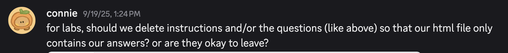

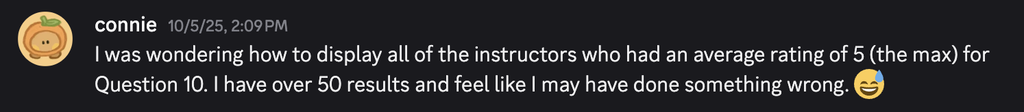

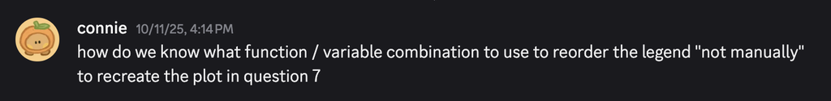